# El impacto del ciclón Yaku en los estudiantes de la Universidad de Ingeniería y Tecnología. Lima, abril 2023.

## Instalación de paquetes

```r
if(!require(dplyr)) {
  install.packages("dplyr")
  library(dplyr)
}
```

```r
if(!require(ggplot2)) {
  install.packages("ggplot2")
  library(ggplot2)
}
```

```r
if(!require(readr)) {
  install.packages("readr")
  library(readr)
}
```

# **1. Introducción**

## 1.1 Relevancia

Los estudiantes se encontraron en medio de desafíos considerables tras la aparición del ciclón “Yaku”. Aunque no todos experimentaron las consecuencias de forma directa, muchos tienen seres queridos que sí se vieron significativamente afectados por este devastador fenómeno natural. El impacto del ciclón podría haber alterado la vida de los estudiantes de diversas formas, ya sea en términos económicos, psicológicos o físicos. Este proyecto tiene como objetivo proporcionar una visión completa de la naturaleza y el alcance del impacto sufrido por los estudiantes de la Universidad de Ingeniería y Tecnología (UTEC). Asimismo, se espera que estos hallazgos sirvan para guiar a las autoridades y a los ciudadanos en la anticipación de situaciones similares en el futuro, minimizando así los daños potenciales en la sociedad.

## 1.2 Objetivos

### 1.2.1 Objetivo general

Investigar y analizar el impacto del ciclón Yaku en los estudiantes de la Universidad de Ingeniería y Tecnología (UTEC) en Lima, en abril de 2023, con el fin de comprender la magnitud de las consecuencias generadas por este fenómeno natural. Esto incluirá evaluar la situación actual de los estudiantes, determinar la proporción de estudiantes afectados, identificar los departamentos más afectados, y explorar cómo la tragedia ha influido en sus estudios, estado de ánimo, y actitud ante la situación. Además, el estudio busca valorar la respuesta y las medidas tomadas por el gobierno y organizaciones de ayuda, la preparación de los estudiantes ante un suceso de esta magnitud, y establecer si han sufrido pérdidas materiales, económicas y ambientales como resultado del ciclón Yaku.

### 1.2.1 Objetivos específicos

1. Conocer la situación en la que se encuentran los estudiantes de UTEC después del fenómeno natural Yaku.
2. Determinar el porcentaje de alumnos afectados.
3. Conocer los departamentos más afectado por el ciclón Yaku.
4. Determinar si el ciclón Yaku afectó el rendimiento académico y estado de ánimo de los estudiantes de UTEC.
5. Conocer la actitud que tomaron los estudiantes ante el ciclón Yaku.
6. Conocer de qué forma afectó el ciclón Yaku a los estudiantes de la UTEC.
7. Evaluar la respuesta por parte del Gobierno y Organizaciones de ayuda frente a daños causados por el ciclón Yaku.
8. Evaluar la preparación de los estudiantes de la UTEC ante un fenómeno natural.
9. Determinar si los estudiantes de UTEC tuvieron perdidas materiales, económicas y ambientales a causa del ciclón Yaku.

## 1.3 Contexto

Después de cuatro décadas, el norte de Perú fue azotado por un ciclón, un fenómeno natural bautizado como “Yaku”, un término que proviene de la lengua quechua y significa “agua”. Este ciclón, caracterizado por su rápida rotación, dejó un rastro de devastación a su paso. Entre las catástrofes provocadas por este suceso, destacaron inundaciones resultantes de las intensas lluvias. Estas afectaron a miles de familias, conduciendo a la pérdida de innumerables bienes materiales.

En respuesta a la magnitud de los daños, las autoridades peruanas declararon un estado de emergencia en varias regiones y movilizaron equipos de rescate y asistencia humanitaria. Su objetivo: brindar apoyo a las numerosas personas damnificadas, las cuales quedaron en situaciones de extrema vulnerabilidad tras el paso del ciclón “Yaku”. A partir de este contexto, nace nuestro estudio estadístico que tiene como objetivo profundizar en la naturaleza y el alcance del impacto sufrido por los estudiantes de la Universidad de Ingeniería y Tecnología (UTEC)

# **2. Datos**

## 2.1 Proceso de recolección de datos

- Es importante mencionar que en cada encuesta realizada, se le pidió al usuario responder con sinceridad y juicio crítico. Esto, pues buscamos disminuir cualquier posibilidad de sesgo asociado a su respuesta.
- Priorizamos encuestar a gente *aleatoria* por la universidad (a excepción de grupos de estudiantes) con el objetivo de no guardar un sesgo de muestras, es decir evitamos dirigirnos a grupos de personas de la misma carrera, pues afectaría a nuestras estadísticas.
- Por otro lado, la encuesta no recopiló dirección de correo, ni código de estudiante, simplemente carrera, edad, género y ciclo académico. Esto lo hicimos con el principal objetivo de no recopilar información innecesaria y sensible, no obstante la encuesta perteneció cerrada para estudiantes de la Universidad de Ingeniería y Tecnología (UTEC) sin recopilación de correos.

## 2.2 Población, muestra y muestreo

- **Población de estudio:** Los estudiantes de la Universidad de Ingeniería y Tecnología (UTEC). Unidad muestral: Los estudiantes que respondieron adecuadamente a la encuesta realizada a través de Google Forms (117 estudiantes)
- **Representatividad de la muestra:** La muestra se considera representativa debido a que se envió de forma masiva a la comunidad estudiantil de pregrado de UTEC a través de grupos de WhatsApp, lo que permitió alcanzar a un número significativo de estudiantes de diferentes carreras y edades. Al obtener 117 observaciones, se logra tener una muestra considerablemente representativa de la población de estudiantes de UTEC.
- **Tipo de muestreo:** En este caso, se utilizó un tipo de muestreo no probabilístico denominado muestreo por conveniencia.Está trata en la disponibilidad y accesibilidad de los elementos de la población. En este caso, se aprovechó la cercanía y la facilidad de comunicación con los estudiantes de UTEC a través de grupos de WhatsApp y el uso de un formulario en línea (Google Forms) para obtener las respuestas. Aunque este tipo de muestreo no garantiza una selección aleatoria y puede presentar sesgos, en este caso, se hizo el esfuerzo de llegar a una muestra representativa dentro de las posibilidades disponibles.

## 2.3 Variables

[output not shown]

# **3. Limpieza de base de datos**

Todas las encuestas realizadas por estudiantes se encuentran dentro de la plataforma de Google Forms guardadas en la nube. Para poder trabajar con aquellas respuestas fue necesario exportarlas a un formato fácil de manipular: `csv.`

## 3.1 Carga de la base de datos

Para trabajar en este proyecto, definimos la variable `DB` como la responsable de almacenar el dataframe obtenido en formato `csv`, transformado por medio de la librería `readr`, en conjunto con su función de lectura `read.csv()` .

```r
# cargar base de datos localizada en directorio actual.
DB <- read.csv("./database.csv")
```

## 3.2 Información inicial

A modo de entender nuestra base de datos, es necesario como primer paso ver la información que ha sido recogida, los tipos de datos, cuántas observaciones (filas) y variables (columnas) están presentes e identificar si existe algún tipo de datos que no corresponde a alguna variable dada, para así corregirlo.

```r
# identificar observaciones
ncol(DB)
```

```
## [1] 22
```

```r
nrow(DB)
```

```
## [1] 254
```

```r
# identificar nombres de variables
colnames(DB)
```

```
##  [1] "Marca.temporal"
##  [2] "Â.Usted.fue.afectado.de.manera.directa.Ã³.indirecta.por.el.ciclÃ³n.Yaku."
##  [3] "Carrera"
##  [4] "GÃ.nero"
##  [5] "Edad...ingrese.un.nÃºmero.entero.y.no.negativo."
##  [6] "Seleccione.el.nÃºmero.de.personas.en.su.vivienda"
##  [7] "Sector.de.nacimiento"
##  [8] "Â.Te.afecto.econÃ³micamente.el.ciclÃ³n.Yaku."
##  [9] "Â.Ha.experimentado.problemas.de.salud.fÃ.sica.o.mental.debido.al.ciclÃ³n.Yaku."
## [10] "Â.Ha.experimentado.interrupciones.en.el.transporte.en.general..incluyendo.transporte.pÃºblico..vehÃ.culo.personal..y.otros.medios.de.transporte.debido.al.ciclÃ³n.Yaku."
## [11] "Â.Ha.sufrido.interrupciones.en.el.acceso.a.la.educaciÃ³n.debido.al.ciclÃ³n.Yaku."
## [12] "Seleccione.su.tipo.de.vivienda"
## [13] "Tipo.de.localidad"
## [14] "Â.CuÃ.l.fue.su.estado.de.Ã.nimo.durante.el.ciclÃ³n."
## [15] "Â.CuÃ.l.fue.su.estado.de.Ã.nimo.despuÃ.s.del.ciclÃ³n."
## [16] "Seleccione.la.forma.de.apoyo.que.brindÃ³"
## [17] "SegÃºn.su.opiniÃ³n..califique.el.grado.de.afectaciÃ³n.del.ciclÃ³n.Yaku"
## [18] "Â.CuÃ.l.es.su.nivel.socioeconÃ³mico."
## [19] "Califique.el.grado.de.satisfacciÃ³n.a.la.respuesta.del.Gobierno"
## [20] "Â.CuÃ.l.cree.usted.que.es.su.nivel.de.preparaciÃ³n.ante.un.fenÃ³meno.natural."
## [21] "Aproximadamente..Â.cuÃ.l.fue.el.gasto.por.los.daÃ.os.ocasionados.por.el.ciclÃ³n.Yaku....Nuevos.soles.S..."
## [22] "Aproximadamente..Â.Con.cuÃ.nto.dinero.apoyaste.a.los.damnificados...Nuevos.soles.S..."
```

## 3.3 Renombrar columnas

Ahora, que ya conocemos las variables, procedemos a eliminar ciertos carácteres prohubidos ó que interfieren en la limpieza e incluso no cumplen con las *mejores prácticas*. Entre estos criterios, consideramos eliminar tildes, espacios, términos en blanco y signos de pregunta (*Google Forms los transformaba a “X”*). Además consideramos apropiado eliminar la variable de marcaTemporal, la cual guardaba registro del día que se realizó la encuesta, pues no es una variable representativa a nuestro objetivo.

```r
# eliminar marca temporal (fecha que se envió la encuesta)
DB$Marca.temporal <- NULL

# leer nombre de columnas actuales
colnames(DB)
```

```
##  [1] "Â.Usted.fue.afectado.de.manera.directa.Ã³.indirecta.por.el.ciclÃ³n.Yaku."
##  [2] "Carrera"
##  [3] "GÃ.nero"
##  [4] "Edad...ingrese.un.nÃºmero.entero.y.no.negativo."
##  [5] "Seleccione.el.nÃºmero.de.personas.en.su.vivienda"
##  [6] "Sector.de.nacimiento"
##  [7] "Â.Te.afecto.econÃ³micamente.el.ciclÃ³n.Yaku."
##  [8] "Â.Ha.experimentado.problemas.de.salud.fÃ.sica.o.mental.debido.al.ciclÃ³n.Yaku."
##  [9] "Â.Ha.experimentado.interrupciones.en.el.transporte.en.general..incluyendo.transporte.pÃºblico..vehÃ.culo.personal..y.otros.medios.de.transporte.debido.al.ciclÃ³n.Yaku."
## [10] "Â.Ha.sufrido.interrupciones.en.el.acceso.a.la.educaciÃ³n.debido.al.ciclÃ³n.Yaku."
## [11] "Seleccione.su.tipo.de.vivienda"
## [12] "Tipo.de.localidad"
## [13] "Â.CuÃ.l.fue.su.estado.de.Ã.nimo.durante.el.ciclÃ³n."
## [14] "Â.CuÃ.l.fue.su.estado.de.Ã.nimo.despuÃ.s.del.ciclÃ³n."
## [15] "Seleccione.la.forma.de.apoyo.que.brindÃ³"
## [16] "SegÃºn.su.opiniÃ³n..califique.el.grado.de.afectaciÃ³n.del.ciclÃ³n.Yaku"
## [17] "Â.CuÃ.l.es.su.nivel.socioeconÃ³mico."
## [18] "Califique.el.grado.de.satisfacciÃ³n.a.la.respuesta.del.Gobierno"
## [19] "Â.CuÃ.l.cree.usted.que.es.su.nivel.de.preparaciÃ³n.ante.un.fenÃ³meno.natural."
## [20] "Aproximadamente..Â.cuÃ.l.fue.el.gasto.por.los.daÃ.os.ocasionados.por.el.ciclÃ³n.Yaku....Nuevos.soles.S..."
## [21] "Aproximadamente..Â.Con.cuÃ.nto.dinero.apoyaste.a.los.damnificados...Nuevos.soles.S..."
```

```r
# actualizar nombre de columnas respetando criterios mencionados.
colnames(DB) <- c(
  "fueAfectado",
  "carrera",
  "genero",
  "edad",
  "personasEnVivienda",
  "sectorNacimiento",
  "afectoEconomicamente",
  "tuvoProblemaSalud",
  "interrupcionTransporte",
  "interrupcionEducacion",
  "tipoVivienda",
  "tipoLocalidad",
  "animoDurante",
  "animoDespues",
  "formaApoyo",
  "gradoAfectacion",
  "nivelSocioeconomico",
  "satisfaccionRespuestaGobierno",
  "nivelPreparacionFenomeno",
  "gastoDañosCiclon",
  "apoyoAfectados"
)

# verificar que se realizó sobreescritura con éxito.
colnames(DB)
```

```
##  [1] "fueAfectado"                   "carrera"
##  [3] "genero"                        "edad"
##  [5] "personasEnVivienda"            "sectorNacimiento"
##  [7] "afectoEconomicamente"          "tuvoProblemaSalud"
##  [9] "interrupcionTransporte"        "interrupcionEducacion"
## [11] "tipoVivienda"                  "tipoLocalidad"
## [13] "animoDurante"                  "animoDespues"
## [15] "formaApoyo"                    "gradoAfectacion"
## [17] "nivelSocioeconomico"           "satisfaccionRespuestaGobierno"
## [19] "nivelPreparacionFenomeno"      "gastoDañosCiclon"
## [21] "apoyoAfectados"
```

## 3.4 Corregir tipos de datos

Ahora, que ya hemos corregido nuestras variables, y es más sencillo el acceder a ellas, procedemos a analizar cada tipo de dato de ellas para corregirlo en caso sea necesario. Para realizar esto evaluamos primero con la función `str(DB)` los tipos actuales, y posteriormente lo actualizamos de acuerdo a nuestro criterio.

```r
# actualizar variables con valores correctos
DB$apoyoAfectados <- as.numeric(DB$apoyoAfectados);
DB$gastoDañosCiclon <- as.numeric(DB$gastoDañosCiclon);
DB$satisfaccionRespuestaGobierno <- as.integer(DB$satisfaccionRespuestaGobierno);
DB$gradoAfectacion <- as.integer(DB$gradoAfectacion);
DB$personasEnVivienda <- as.integer(DB$personasEnVivienda);
DB$edad <- as.integer(DB$edad);
DB$sectorNacimiento <- as.character(DB$sectorNacimiento);
DB$genero <- as.character(DB$genero);

# logica para covertir a valores booleanos
DB$interrupcionEducacion <- ifelse(DB$interrupcionEducacion=="Si", TRUE, FALSE);
DB$interrupcionTransporte <- ifelse(DB$interrupcionTransporte=="Si", TRUE, FALSE);
DB$tuvoProblemaSalud <- ifelse(DB$tuvoProblemaSalud=="Si", TRUE, FALSE);
DB$afectoEconomicamente <- ifelse(DB$afectoEconomicamente=="Si", TRUE, FALSE);
DB$fueAfectado <- ifelse(DB$fueAfectado=="Sí", TRUE, FALSE);
```

En el caso expuesto corregimos las variables: *apoyoAfectados, gastoDañosCiclón, satisfaccionRespuestaGobierno, gradoAfectacion, personasEnVivienda, edad, sectorNacimiento, genero.* En su mayoría a variables numéricas, enteras ó del tipo carácter.

Por otro lado para ciertas variables del tipo pregunta binaria, corregimos su tipo a booleanos, pues es más sencillo evaluar un TRUE, FALSE. Las implicadas son: *interrupcionEducacion, interrupcionTransporte, tuvoProblemaSalud, afectoEconomicamente, fueAfectado.*

## 3.5 Corregir error de NA’s

Para verificar si nuestra Base de Datos almacena valores NA es decir, valores no aplicables al tipo de variable, valores vacíos ó valores sin relación con la pregunta. Para ello, primero debemos aclarar que nuestra base de datos tiene una *pregunta filtro*, es la encargada de determinar si el estudiante fue afectado ó no.

A partir de esta pregunta podemos filtrar los NA para estudiantes afectados, por lo que debemos de evaluar esa condición primero. Por otro lado en campo de texto abiertos (el usuario ingresa la data, no la marca) es necesario filtrar aquellos que están vacíos, como es el caso de la variable `gastoDañosCiclon(DB)`.

```r
# verificar sobreescritura de datos
summary(DB)
```

```
##  fueAfectado       carrera             genero               edad
##  Mode :logical   Length:254         Length:254         Min.   :17.00
##  FALSE:254       Class :character   Class :character   1st Qu.:18.00
##                  Mode  :character   Mode  :character   Median :19.00
##                                                        Mean   :19.59
##                                                        3rd Qu.:21.00
##                                                        Max.   :26.00
##                                                        NA's   :136
##  personasEnVivienda sectorNacimiento   afectoEconomicamente tuvoProblemaSalud
##  Min.   : 1.00      Length:254         Mode :logical        Mode :logical
##  1st Qu.: 3.00      Class :character   FALSE:176            FALSE:198
##  Median : 5.00      Mode  :character   TRUE :78             TRUE :56
##  Mean   : 4.78
##  3rd Qu.: 6.00
##  Max.   :10.00
##  NA's   :136
##  interrupcionTransporte interrupcionEducacion tipoVivienda
##  Mode :logical          Mode :logical         Length:254
##  FALSE:178              FALSE:201             Class :character
##  TRUE :76               TRUE :53              Mode  :character
##
##
##
##
##  tipoLocalidad      animoDurante       animoDespues        formaApoyo
##  Length:254         Length:254         Length:254         Length:254
##  Class :character   Class :character   Class :character   Class :character
##  Mode  :character   Mode  :character   Mode  :character   Mode  :character
##
##
##
##
##  gradoAfectacion  nivelSocioeconomico satisfaccionRespuestaGobierno
##  Min.   : 1.000   Length:254          Min.   : 1.000
##  1st Qu.: 4.000   Class :character    1st Qu.: 3.000
##  Median : 6.000   Mode  :character    Median : 5.000
##  Mean   : 5.771                       Mean   : 4.881
##  3rd Qu.: 8.000                       3rd Qu.: 7.000
##  Max.   :10.000                       Max.   :10.000
##  NA's   :136                          NA's   :136
##  nivelPreparacionFenomeno gastoDañosCiclon apoyoAfectados
##  Length:254               Min.   :   0.0   Min.   :   0.0
##  Class :character         1st Qu.:  97.0   1st Qu.:   4.0
##  Mode  :character         Median : 262.0   Median : 111.0
##                           Mean   : 394.6   Mean   : 193.1
##                           3rd Qu.: 402.0   3rd Qu.: 331.2
##                           Max.   :4000.0   Max.   :2000.0
##                           NA's   :137      NA's   :136
```

```r
# No existen datos faltantes.
(sum(is.na(DB))/(nrow(DB)*ncol(DB))*100)
```

```
## [1] 15.31684
```

## 3.6 Corregir errores con cuantiles

### 3.6.1 Variable gastoDañosCiclón

```r
IQR(DB$gastoDañosCiclon, na.rm=TRUE); # 303.25, se encuentran 50% de datos
```

```
## [1] 305
```

```r
quantile(DB$gastoDañosCiclon, 0.25, na.rm = TRUE) # 25% de datos <= 99.25
```

```
## 25%
##  97
```

```r
quantile(DB$gastoDañosCiclon, 0.75, na.rm = TRUE) # 75% de datos <= 402.5
```

```
## 75%
## 402
```

Utilizando el diagrama de cajas y bigotes (boxplot), pudimos visualizar esta concentración de datos y la dispersión que existe fuera de este rango. En consecuencia, justificadamente decidimos eliminar los valores atípicos, ya que estos aportaban una variabilidad excesiva que podía distorsionar nuestros análisis.

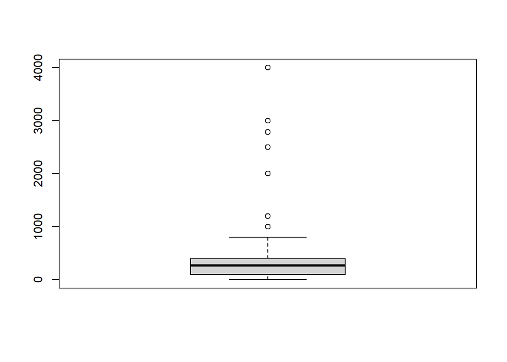

```r
# almacenar valores atípicos del diagrama boxplot (circulos)
atipicoGastoDanosCiclon <- boxplot(DB$gastoDañosCiclon)$out
```

```r
# quitar valores atípicos de los datos (4000, 3000, 2000, 1000)
DB_FINAL <- DB;
DB_FINAL <- subset(DB, !gastoDañosCiclon %in% atipicoGastoDanosCiclon)
```

En el último apartado gracias a nuestra visualización del diagrama **boxplot**, fue posible eliminar valores atípicos, que estaban fuera del rango intercuartil y además no eran representativos, gracias a su eliminación nuestra muestra sigue siendo representativa.

```r
cat("* Antes: \n")
```

```
## * Antes:
```

```r
summary(DB$gastoDañosCiclon)
```

```
##    Min. 1st Qu.  Median    Mean 3rd Qu.    Max.    NA's
##     0.0    97.0   262.0   394.6   402.0  4000.0     137
```

```r
cat("* Después: \n")
```

```
## * Después:
```

```r
summary(DB_FINAL$gastoDañosCiclon)
```

```
##    Min. 1st Qu.  Median    Mean 3rd Qu.    Max.    NA's
##     0.0    76.0   200.0   218.1   347.0   800.0     137
```

- Antes de la eliminación de los valores atípicos, la media era de $S/. 394.6$ y el valor máximo era de $S/. 4,000$. El primer y tercer cuartil se situaban en $S/. 97.0$ y $S/. 402.0$, respectivamente.
- Después de eliminar los valores atípicos, la media disminuyó a $S/. 218.1$ y el valor máximo se redujo a $S/. 800$. El primer cuartil disminuyó a $S/. 76.0$ y el tercer cuartil bajó a $S/. 347.0$.

### 3.6.2 Variable apoyoAfectados

```r
IQR(DB$apoyoAfectados, na.rm=TRUE) # 325.5, se encuentran 50% de datos
```

```
## [1] 327.25
```

```r
quantile(DB$apoyoAfectados, 0.25, na.rm = TRUE) # 25% de datos <= 8
```

```
## 25%
##   4
```

```r
quantile(DB$apoyoAfectados, 0.75, na.rm = TRUE) # 75% de datos <= 333.5
```

```
##    75%
## 331.25
```

Por otro lado, es notable que la cifra de S/. 2000 se encuentra bastante alejada del rango intercuartil, mostrando una alta dispersión. Dada esta observación, estamos justificados en eliminar este valor de nuestra muestra. Esta decisión se toma porque su inclusión podría sesgar o distorsionar nuestro análisis, dado que este valor no parece ser representativo de la mayoría de los datos recogidos.

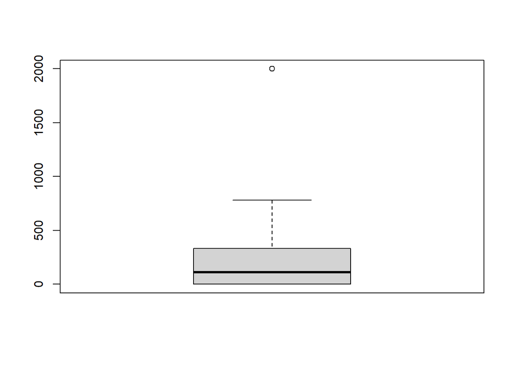

```r
# diagrama de boxplot.
boxplot(DB$apoyoAfectados);
```

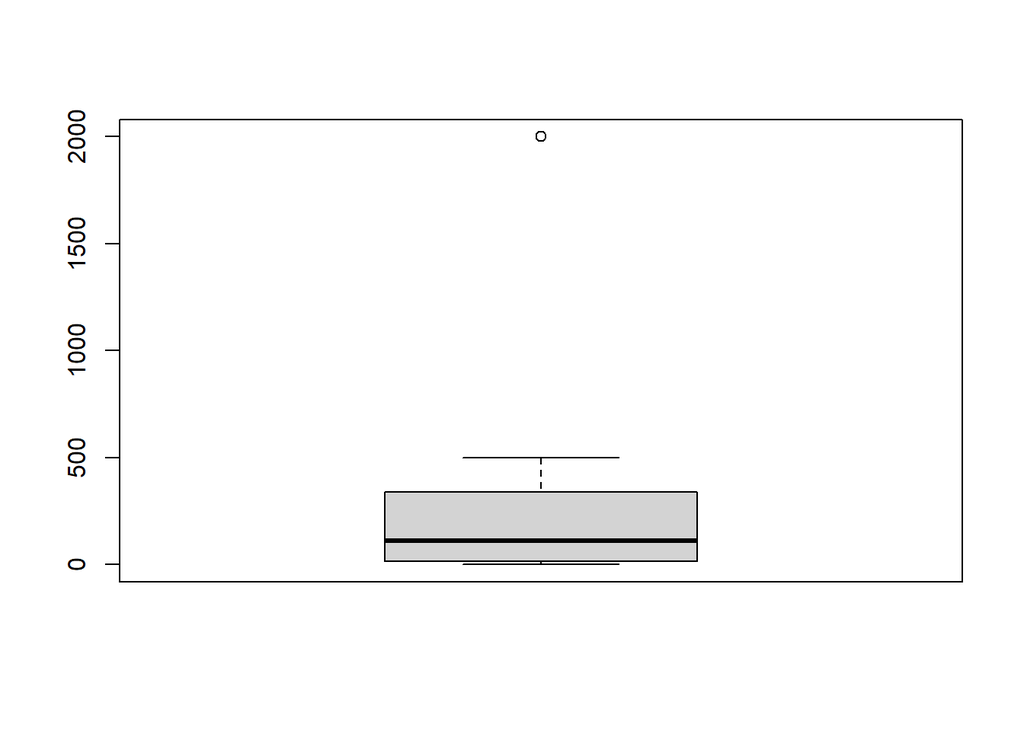

```r
# almacenar valores atípicos del diagrama boxplot (circulos)
atipicoApoyoAfectados <- boxplot(DB_FINAL$apoyoAfectados)$out
```

```r
# quitar valores atípicos de los datos (4000, 3000, 2000, 1000)
DB_FINAL <- subset(DB_FINAL, !apoyoAfectados %in% atipicoApoyoAfectados)
```

Ahora, podemos utilizar la función `summary()` que nos permitirá comparar entre las dos Base de Datos (`DB`, `DB_FINAL`) para la misma variable: `apoyoAfectados`, de esa forma será sencillo notar los cambios que ocasionó la limpieza de boxplot. Además a partir de ello es posible determinar las siguientes conclusiones.

```r
cat("* Antes: \n")
```

```
## * Antes:
```

```r
summary(DB$apoyoAfectados);
```

```
##    Min. 1st Qu.  Median    Mean 3rd Qu.    Max.    NA's
##     0.0     4.0   111.0   193.1   331.2  2000.0     136
```

```r
cat("* Después: \n")
```

```
## * Después:
```

```r
summary(DB_FINAL$apoyoAfectados)
```

```
##    Min. 1st Qu.  Median    Mean 3rd Qu.    Max.    NA's
##     0.0    14.5   111.0   177.9   333.5   500.0     136
```

# 4**. Análisis Descriptivo**

## 4.1 Variable edad

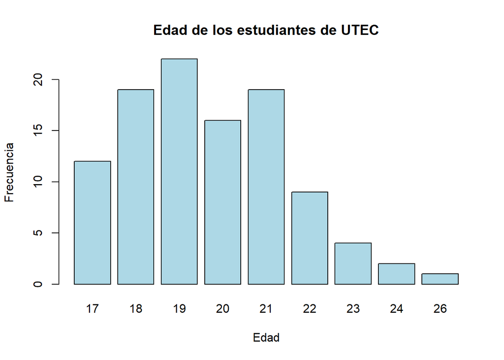

```r
TABLA_FINAL <- table(DB_FINAL$edad[!is.na(DB_FINAL$edad)]);
# verificacion
#frecuencia <- table(edad_no_na)
#valor_mas_repetido <- as.numeric(names(frecuencia)[which.max(frecuencia)])
barplot(
  TABLA_FINAL,
  main = "Edad de los estudiantes de UTEC",
  xlab = "Edad",
  ylab = "Frecuencia",
  col = "lightblue"
)
```

Como se puede apreciar el barplot nos muestra que los estudiantes con mayor frecuencia tienen 19 años. Si bien el gráfico de barras es utilizado para variables categóricas también puede ser empleado para variables numéricas discretas ya que se puede agrupar en rangos o categorías y las barras representan la proporción de cada categoría de está manera este gráfico nos ayuda con la comparación y visualizar tendencias en los datos.

### 4.1.1 Descriptores numéricos

```r
cat('Número de observaciones:', nrow(DB_FINAL),'\n')
```

```
## Número de observaciones: 240
```

```r
cat('Número de casos completos de la variable edad:', sum(complete.cases(DB_FINAL$edad)),'\n')
```

```
## Número de casos completos de la variable edad: 104
```

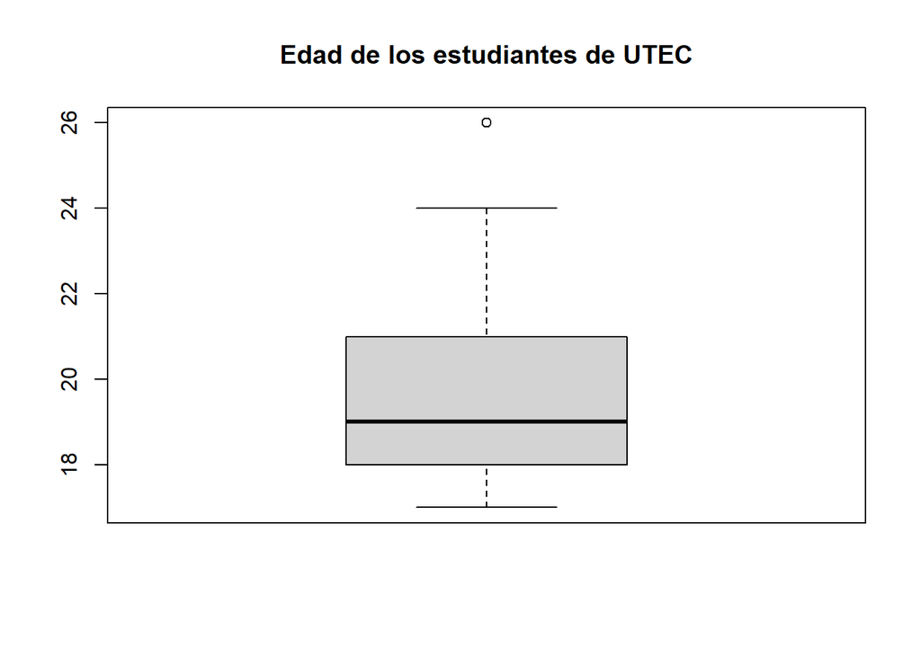

```r
boxplot(DB_FINAL$edad, main = "Edad de los estudiantes de UTEC")
```

### 4.1.2 Datos Estadísticos generales

```r
df_edad = DB_FINAL$edad[!is.na(DB_FINAL$edad)];

cat('1. Mediana de la variable edad:',round(median(df_edad, na.rm=TRUE),2),'\n')
```

```
## 1. Mediana de la variable edad: 19
```

```r
cat('2. Moda de la variable edad:',18 ,'\n')
```

[output not shown]

```r
cat('3. Varianza de la variable edad:',round(var(df_edad, na.rm=TRUE),2),'\n')
```

```
## 3. Varianza de la variable edad: 3.44
```

```r
cat('4. Desviación estándar de la variable edad:',round(sd(df_edad, na.rm=TRUE),2),'\n')
```

```
## 4. Desviación estándar de la variable edad: 1.86
```

```r
cat('5. Coeficiente de variación de la variable edad:', round((sd(df_edad, na.rm=TRUE)/mean(df_edad, na.rm=TRUE))*100,2),'\n')
```

```
## 5. Coeficiente de variación de la variable edad: 9.43
```

## 4.2 Variable Género

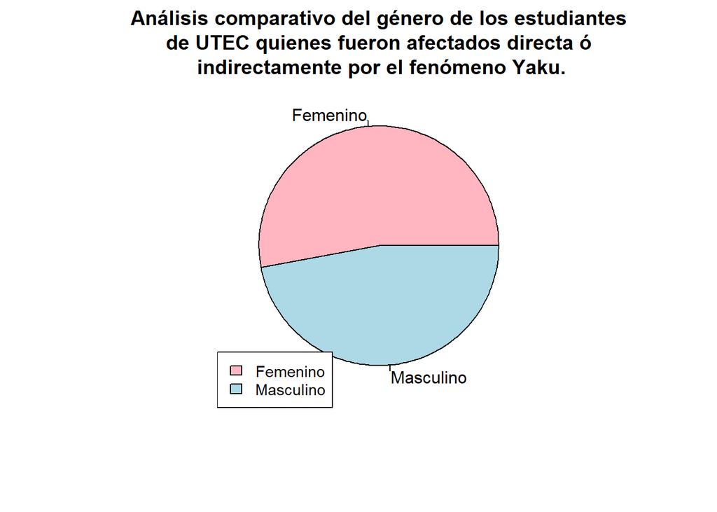

```r
par(pty = "s")  # Configura el área de trazado para ser cuadrada

TABLA<-table(DB_FINAL$genero);

# Filtrar solo los elementos no vacíos
elementos_no_vacios <- names(TABLA)[nzchar(names(TABLA))]
TABLA_FINAL <- TABLA[elementos_no_vacios]

# names(TABLA) -> ORDEN: False, True
colores <- c("lightpink", "lightblue");
labels <- c("Femenino", "Masculino");

pie(
  TABLA_FINAL,
  main = "\n Análisis comparativo del género de los estudiantes \n de UTEC quienes fueron afectados directa ó \n indirectamente por el fenómeno Yaku.\n",
  col = colores,
  col.main = "black",
  labels = labels
);

# leyenda
legend("bottomleft", legend = labels, fill = colores, cex = 0.9)
```

Este tipo de gráfico analiza las variables categóricas , nos muestra la proporción de cada categoría y es fácil de comprender y visualizar los porcentajes y así inferir en un análisis coherente.

### 4.2.1 Descriptores numéricos

```r
cat('Número de observaciones:', nrow(DB_FINAL),'\n')
```

```
## Número de observaciones: 240
```

```r
cat('Número de casos completos de la variable género:', sum(nchar(DB_FINAL$genero) > 0),'\n')
```

```
## Número de casos completos de la variable género: 104
```

### 4.2.2 Datos Estadísticos generales

Se visualiza de la variable cualittiva género que de el total de encuestados de nuestro estudio el género más frecuente es el **femenino**

```r
categorias <- DB_FINAL$genero[DB_FINAL$genero != ""];
frec <- table(categorias)

categoria_mas_frecuente <- names(frec)[frec == max(frec)];

# obtener cantidad de observaciones del tipo femenino
obs_categoria_frecuente <- length(DB_FINAL$genero[DB_FINAL$genero == "Femenino"])
obs_categoria_segunda_frecuente <- length(DB_FINAL$genero[DB_FINAL$genero == "Masculino"])

# Mostrar las estadísticas descriptivas de la variable "sectorNacimiento"
cat('1. Género más frecuente:', categoria_mas_frecuente, '\n')
```

```
## 1. Género más frecuente: Femenino
```

```r
cat('2. Observaciones del género más frecuente:', obs_categoria_frecuente, '\n')
```

```
## 2. Observaciones del género más frecuente: 55
```

```r
cat('3. Observaciones del género menos frecuente:', obs_categoria_segunda_frecuente, '\n')
```

```
## 3. Observaciones del género menos frecuente: 49
```

## 4.3 Variable Sector de Nacimiento

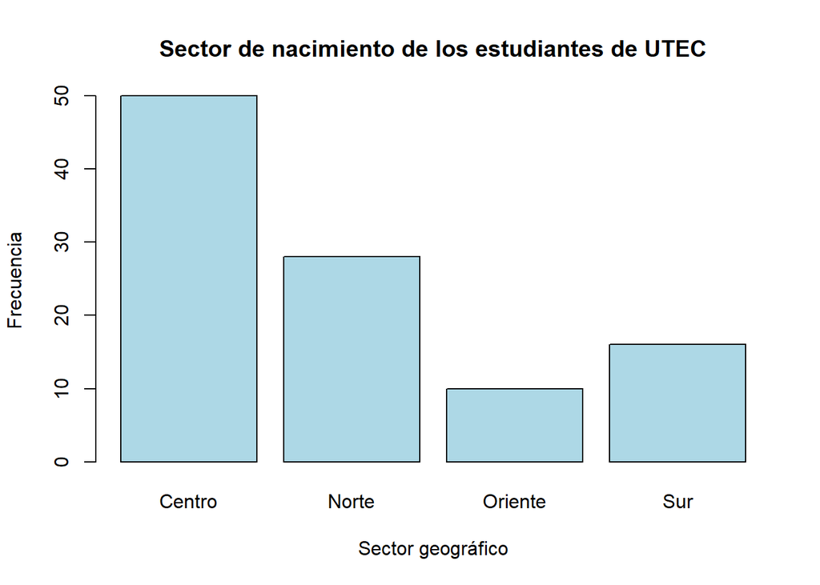

```r
TABLA<-table(DB_FINAL$sectorNacimiento);

# Filtrar solo los elementos no vacíos
elementos_no_vacios <- names(TABLA)[nzchar(names(TABLA))]

# Crear una nueva tabla solo con los elementos no vacíos
TABLA_FINAL <- TABLA[elementos_no_vacios]
# names(TABLA_FINAL) -> Obtener orden de labels.

# Obtener orden de los nombres de las categorías
orden_nombres <- names(TABLA_FINAL)

# Truncar los nombres a la longitud máxima
nombres_cortados <- sapply(strsplit(orden_nombres, " "), function(x) x[[1]])

barplot(
  TABLA_FINAL,
  main = "Sector de nacimiento de los estudiantes de UTEC",
  xlab = "Sector geográfico",
  ylab = "Frecuencia",
  names.arg = nombres_cortados,
  col = c("lightblue"))
```

### 4.3.1 Descriptores numéricos

```r
cat('Número de observaciones:', nrow(DB_FINAL),'\n')
```

```
## Número de observaciones: 240
```

```r
cat('Número de casos completos de la variable lugar de residencia:', sum(nchar(DB_FINAL$sectorNacimiento) > 0),'\n') # utilizar nchar pues es character.
```

```
## Número de casos completos de la variable lugar de residencia: 104
```

Lo que se puede inferir del siguiente resultado es que obtenemos valores completos debajo de la mitad de nuestros encuestados , por lo que nuestro estudio carece de información , cierto sesgo en nuestro análisis , lo que afecta a la representatividad en la muestra y no se pueda tener una confiabilidad en los resultados.

### 4.3.2 Datos Estadísticos generales

```r
# Calcular la frecuencia de cada categoría en la variable "sectorNacimiento"
# Utilizando nzchar obtenemos los strings no vacíos.
categorias <- DB_FINAL$sectorNacimiento[DB_FINAL$sectorNacimiento != ""]
frec <- table(categorias)

categoria_mas_frecuente <- names(frec)[frec == max(frec)]
categoria_min <- strsplit(categoria_mas_frecuente, " ")[[1]][1]

# Mostrar las estadísticas descriptivas de la variable "sectorNacimiento"
cat('1. Categoría más frecuente (MODA) en "sectorNacimiento":', categoria_min, '\n')
```

```
## 1. Categoría más frecuente (MODA) en "sectorNacimiento": Centro
```

## 4.4 Variable Fue Afectado

```r
DB_FINAL
```

[output not shown]

[output cut: 2154 more lines]

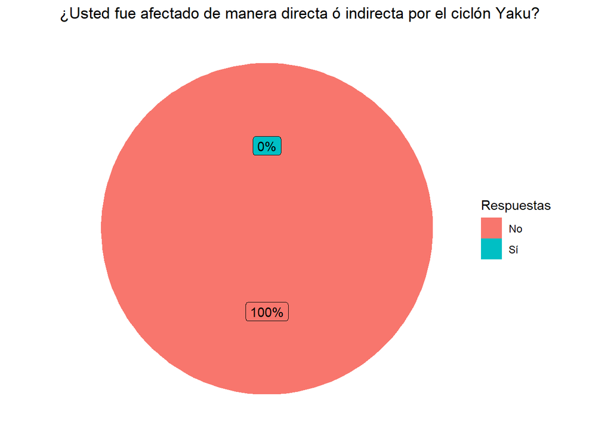

```r
afectados <- sum(DB$fueAfectado == TRUE)
noAfectados <- sum(DB$fueAfectado == FALSE)


afectadosVector <- c(afectados,noAfectados)
categoria <- c("Sí","No");

tablaAfectados <- data.frame(afectadosVector,categoria)
tablaAfectados$porcentaje <- round(tablaAfectados$afectadosVector / sum(tablaAfectados$afectadosVector) * 100,2)


ggplot(tablaAfectados,
  col = colores,
       aes(
  x = "",
  y = afectadosVector, fill = categoria)) +
  geom_bar(stat = "identity", width = 1) +
  coord_polar("y", start = 0) +
  theme_void() +
  labs(fill = "Respuestas") +
  geom_label(aes(label = paste0(porcentaje, "%")), position = position_stack(vjust = 0.5)) +
  ggtitle("¿Usted fue afectado de manera directa ó indirecta por el ciclón Yaku?") +
  guides(fill = guide_legend(override.aes = list(label = "")))
```

### 4.4.1 Descriptores numéricos

```r
afectados_df <- complete.cases(DB_FINAL$fueAfectado[DB_FINAL$fueAfectado == TRUE]);
noafectados_df <- complete.cases(DB_FINAL$fueAfectado[DB_FINAL$fueAfectado == FALSE]);

cat('1. Número de observaciones:', nrow(DB_FINAL),'\n')
```

```
## 1. Número de observaciones: 240
```

```r
cat('2. Número de casos completos que los estudiantes no fueron afectados:', sum(afectados_df),'\n')
```

[output not shown]

```r
 cat('2. Número de casos completos que los estudiantes fueron afectados:', sum(noafectados_df),'\n')# utilizar nchar pues es character.
```

[output not shown]

### 4.4.2 Datos Estadísticos generales

A partir de los resultados obtenidos, es posible determinar que para la mayoría de encuestados (población) no se vieron afectados directa ó indirectamente por el ciclón Yaku.

```r
# Calcular la frecuencia de cada categoría en la variable "sectorNacimiento"
# Utilizando nzchar obtenemos los strings no vacíos.
categorias <- DB_FINAL$fueAfectado
frec <- table(categorias)

categoria_mas_frecuente <- names(frec)[frec == max(frec)]
categoria_min <- strsplit(categoria_mas_frecuente, " ")[[1]][1]

# Mostrar las estadísticas descriptivas de la variable "sectorNacimiento"
cat('1. Respuesta más frecuente, para variable "fue afectado":', categoria_min, '\n')
```

```
## 1. Respuesta más frecuente, para variable "fue afectado": FALSE
```

## 4.5 Variable Afectado Económicamente

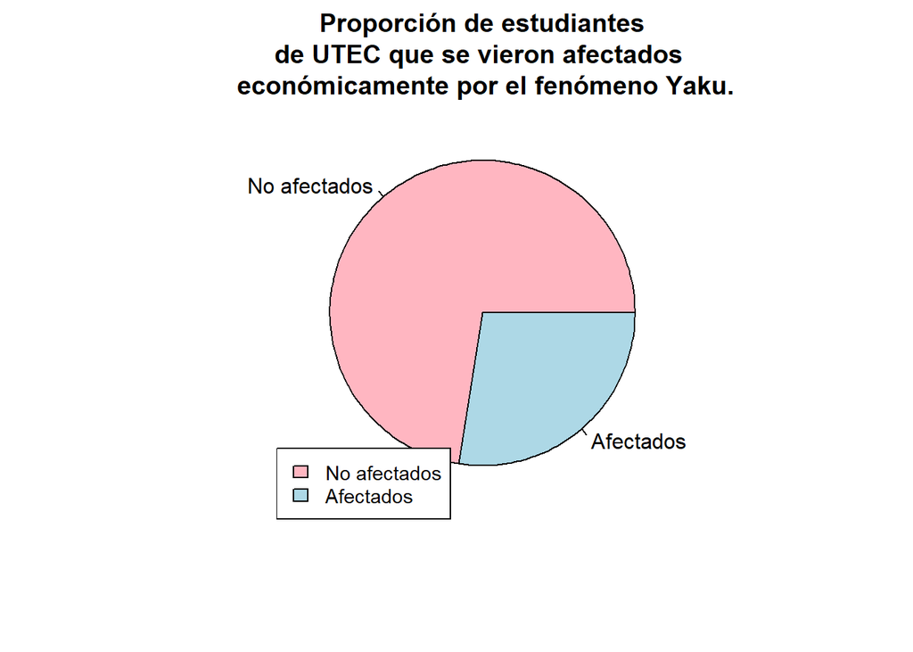

```r
par(pty = "s")  # Configura el área de trazado para ser cuadrada

TABLA<-table(DB_FINAL$afectoEconomicamente);

# Filtrar solo los elementos no vacíos
elementos_no_vacios <- names(TABLA)[nzchar(names(TABLA))]
TABLA_FINAL <- TABLA[elementos_no_vacios]

# names(TABLA) -> ORDEN: False, True
colores <- c("lightpink", "lightblue");
labels <- c("No afectados", "Afectados");

pie(
  TABLA_FINAL,
  main = "\n Proporción de estudiantes \n de UTEC que se vieron afectados  \n económicamente por el fenómeno Yaku.\n",
  col = colores,
  col.main = "black",
  labels = labels
);

# leyenda
legend("bottomleft", legend = labels, fill = colores, cex = 0.9)
```

A partir del gráfico de torta se observa la distribución de cada categoría percibiendo así que en mayor proporción los encuestados respondieron que no se vieron afectados económicamente .

### 4.5.1 Descriptores numéricos

```r
casos_completos <- complete.cases(DB_FINAL$fueAfectado);
afectados_df <- complete.cases(DB_FINAL$fueAfectado[DB_FINAL$afectoEconomicamente == TRUE]);
noafectados_df <- complete.cases(DB_FINAL$fueAfectado[DB_FINAL$afectoEconomicamente == FALSE]);

cat('1. Número de observaciones:', nrow(DB_FINAL),'\n')
```

```
## 1. Número de observaciones: 240
```

```r
cat('2. Número de casos completos que los estudiantes afectados:', sum(afectados_df),'\n')
```

```
## 2. Número de casos completos que los estudiantes afectados: 66
```

```r
 cat('3. Número de casos completos que los estudiantes que no fueron afectados:', sum(noafectados_df),'\n')# utilizar nchar pues es character.
```

```
## 3. Número de casos completos que los estudiantes que no fueron afectados: 174
```

```r
porcentaje_afectados = round((sum(afectados_df) / sum(casos_completos)) * 100, 2) ;
  cat('4. Porcentaje de estudiantes afectados económicamente:', porcentaje_afectados,'%\n')
```

```
## 4. Porcentaje de estudiantes afectados económicamente: 27.5 %
```

```r
porcentaje_noafectados = round((sum(noafectados_df) / sum(casos_completos)) * 100, 2) ;
  cat('4. Porcentaje de estudiantes no afectados económicamente:', porcentaje_noafectados,'%\n')
```

```
## 4. Porcentaje de estudiantes no afectados económicamente: 72.5 %
```

## 4.6 Variable Gasto total en daños

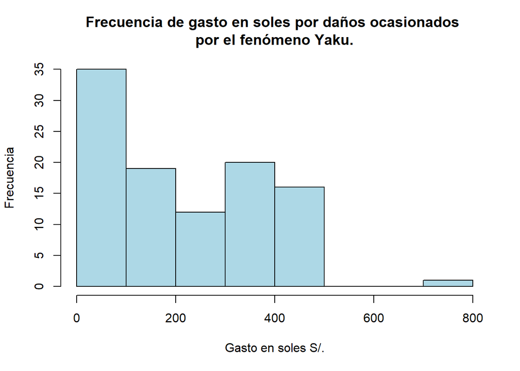

```r
library(ggplot2)
TABLA <- (DB_FINAL$gastoDañosCiclon)

# Filtrar y ajustar los valores de gasto por daños
gasto_danos <- DB_FINAL$gastoDañosCiclon
gasto_danos[gasto_danos < 0] <- 0
gasto_danos[gasto_danos > 800] <- 800

# Crear los rangos de valores
rangos <- cut(gasto_danos, breaks = c(0, 200, 400, 600, 800))

# Crear el data frame para el gráfico
data <- data.frame(Gasto = gasto_danos, Rango = rangos)

# Definir los colores para cada rango
colores <- c("lightblue")

# Crear el histograma con colores agrupados por rangos
hist(
  x = TABLA,
  xlab = "Gasto en soles S/.",
  ylab = "Frecuencia",
  main = "Frecuencia de gasto en soles por daños ocasionados \n por el fenómeno Yaku. ",
  col = colores
)
```

El gráfico de barras nos proporciona un resumen de datos, con ello hacer un análisis comparativo se puede distinguir la barra más sobresaliente entre todas es cuando el gasto se ubica en **0-100**$ lo que nos da una idea que el gasto en soles ocasionado por el fenómeno Yaku más frecuente no fue muy alto.

### 4.6.1 Descriptores numéricos

```r
df_gasto_danos = DB_FINAL$gastoDañosCiclon[!is.na(DB_FINAL$gastoDañosCiclon)];

cat('1. Mediana de la variable gasto daños:',round(median(df_gasto_danos, na.rm=TRUE),2),'\n')
```

```
## 1. Mediana de la variable gasto daños: 200
```

```r
cat('2. Moda de la variable gasto daños:',18 ,'\n')
```

[output not shown]

```r
cat('3. Varianza de la variable gasto daños:',round(var(df_gasto_danos, na.rm=TRUE),2),'\n')
```

```
## 3. Varianza de la variable gasto daños: 28798.04
```

```r
cat('4. Desviación estándar de la variable gasto daños:',round(sd(df_gasto_danos, na.rm=TRUE),2),'\n')
```

```
## 4. Desviación estándar de la variable gasto daños: 169.7
```

```r
cat('5. Coeficiente de variación de la variable gasto daños:', round((sd(df_gasto_danos, na.rm=TRUE)/mean(df_gasto_danos, na.rm=TRUE))*100,2),'\n')
```

```
## 5. Coeficiente de variación de la variable gasto daños: 77.06
```

A partir de lo obtenido, deducimos que al tener una varianza, coeficiente de variación y desviación de estándar alta nos indica que hay una dispersión con relación a la media y pueden estar dispersos a lo largo del rango , lo que nos podría indicar que existe una gran variabilidad y posiblemente se tenga valores atípicos o extremos en el conjunto de datos.

# **7. Bibliografía**

- Redacción Gestión.29 de Marzo del 2023. ¿Qué es el ciclón Yaku y por qué afecta a la costa de Perú?.Gestión. https://gestion.pe/peru/ciclon-yaku-que-es-y-como-se-genera-peru-nnda-nnlt-noticia/?outputType=amp